# Räumliche & Zeitliche Ausbreitung von Corona

Kyrill Guba, Colin Linke, Batuhan Güyelkaya, Vaishali Iyer

2023-01-12

```r
df4 <- read.csv("df4.csv", header = TRUE, sep = ",")
df4_pan<-pdata.frame(df4,index=c("district","week"))
```

Hotspot Variable definiert als: doppelt so hoch wie die Inzidenz zur Vorwoche & doppelt so hoch wie die Inzidenz der Nachbarorte

Hotspotnb Variable deifiniert als: mindestens ein Nachbarort gilt als Hotspot

```r
table(df4_pan$hotspot)
```

```
##
## FALSE  TRUE
## 13769   439
```

```r
table(df4_pan$hotspotnb)
```

```
##
## FALSE  TRUE
## 13266   942
```

Entscheidung zwischen random effects und fixed effects, mit Hilfe des Hausman-Tests:

```r
fe.step0 <- plm(inzidenz ~ lag(inzidenz, 1) + lag(weightednbinz, 1)
              + I(log(density)*lag(inzidenz, 1))
              + factor(week)
               , data =df4_pan, model = "within")

re.step0 <- plm(inzidenz ~ lag(inzidenz, 1) + lag(weightednbinz, 1)
    + I(log(density)*lag(inzidenz, 1))
    + factor(week)
    , data =df4_pan, model = "random")

phtest(fe.step0, re.step0)
```

```
##
##  Hausman Test
##
## data:  inzidenz ~ lag(inzidenz, 1) + lag(weightednbinz, 1) + I(log(density) *  ...
## chisq = 117.28, df = 149, p-value = 0.9743
## alternative hypothesis: one model is inconsistent
```

p-value>0.05, deswegen random effects.

Schrittweise Modellselektion mit Hilfe von F-Test für panel-data:

```r
re.step0 <- plm(inzidenz ~ lag(inzidenz, 1) + lag(weightednbinz, 1)
                + I(log(density)*lag(inzidenz, 1))
                + factor(week)
                , data =df4_pan, model = "random")

#summary(re.step0)

re.step1 <- plm(inzidenz ~ lag(inzidenz, 1) + lag(weightednbinz, 1)
                + I(log(density)*lag(inzidenz, 1)) + I(hotspot * lag(inzidenz, 1))
                + factor(week)
                , data =df4_pan, model = "random")

pFtest(re.step1, re.step0)
```

```
##
##  F test for individual effects
##
## data:  inzidenz ~ lag(inzidenz, 1) + lag(weightednbinz, 1) + I(log(density) *  ...
## F = 60.859, df1 = 1, df2 = 13961, p-value = 6.566e-15
## alternative hypothesis: significant effects
```

```r
## include: hotspot*inzidenz

re.step1.5 <- plm(inzidenz ~ lag(inzidenz, 1) + lag(weightednbinz, 1)
                  + I(log(density)*lag(inzidenz, 1)) + I(hotspot * lag(inzidenz, 1))
                  + I(hotspotnb * lag(weightednbinz, 1))
                  + factor(week)
                  , data =df4_pan, model = "random")

pFtest(re.step1.5, re.step1)
```

```
##
##  F test for individual effects
##
## data:  inzidenz ~ lag(inzidenz, 1) + lag(weightednbinz, 1) + I(log(density) *  ...
## F = 7.807, df1 = 1, df2 = 13960, p-value = 0.005212
## alternative hypothesis: significant effects
```

```r
## include: hotspotnb*inzidenz

re.step2 <- plm(inzidenz ~ lag(inzidenz, 1) + lag(weightednbinz, 1)
                + I(log(density)*lag(inzidenz, 1)) + I(hotspot * lag(inzidenz, 1))
                +I(hotspotnb * lag(weightednbinz, 1))
                + rate_zweitimpf
                + factor(week)
                , data =df4_pan, model = "random")

pFtest(re.step2, re.step1.5)
```

```
##
##  F test for individual effects
##
## data:  inzidenz ~ lag(inzidenz, 1) + lag(weightednbinz, 1) + I(log(density) *  ...
## F = 0.39688, df1 = 1, df2 = 13959, p-value = 0.5287
## alternative hypothesis: significant effects
```

```r
## reject rate_zweitimpf


re.step2.5 <- plm(inzidenz ~ lag(inzidenz, 1) + lag(weightednbinz, 1)
                  + I(log(density)*lag(inzidenz, 1)) + I(hotspot * lag(inzidenz, 1))
                  + I(hotspotnb * lag(weightednbinz, 1)) + I(rate_zweitimpf * hotspot)
                  + factor(week)
                  , data =df4_pan, model = "random")

pFtest(re.step2.5, re.step1.5)
```

```
##
##  F test for individual effects
##
## data:  inzidenz ~ lag(inzidenz, 1) + lag(weightednbinz, 1) + I(log(density) *  ...
## F = 4.7866, df1 = 1, df2 = 13959, p-value = 0.0287
## alternative hypothesis: significant effects
```

```r
## include rate_zweitimpf * hotspot


re.step3 <- plm(inzidenz ~ lag(inzidenz, 1) + lag(weightednbinz, 1)
                + I(log(density)*lag(inzidenz, 1)) + I(hotspot * lag(inzidenz, 1))
                +I(hotspotnb * lag(weightednbinz, 1)) + I(rate_zweitimpf * hotspot)
                + A60.79.Anteil
                + factor(week)
                , data =df4_pan, model = "random")

pFtest(re.step3, re.step2.5)
```

```
##
##  F test for individual effects
##
## data:  inzidenz ~ lag(inzidenz, 1) + lag(weightednbinz, 1) + I(log(density) *  ...
## F = 4.5389, df1 = 1, df2 = 13958, p-value = 0.03315
## alternative hypothesis: significant effects
```

```r
## include A60.79.Anteil


re.step4 <- plm(inzidenz ~ lag(inzidenz, 1) + lag(weightednbinz, 1)
                + I(log(density)*lag(inzidenz, 1)) + I(hotspot * lag(inzidenz, 1))
                +I(hotspotnb * lag(weightednbinz, 1)) + I(rate_zweitimpf * hotspot)
                + A60.79.Anteil + A35.59.Anteil
                + factor(week)
                , data =df4_pan, model = "random")

pFtest(re.step4, re.step3)
```

```
##
##  F test for individual effects
##
## data:  inzidenz ~ lag(inzidenz, 1) + lag(weightednbinz, 1) + I(log(density) *  ...
## F = 1.8603, df1 = 1, df2 = 13957, p-value = 0.1726
## alternative hypothesis: significant effects
```

```r
re.step4.5 <- plm(inzidenz ~ lag(inzidenz, 1) + lag(weightednbinz, 1)
                  + I(log(density)*lag(inzidenz, 1)) + I(hotspot * lag(inzidenz, 1))
                  +I(hotspotnb * lag(weightednbinz, 1)) + I(rate_zweitimpf * hotspot)
                  + A35.59.Anteil
                  + factor(week)
                  , data =df4_pan, model = "random")

pFtest(re.step4.5, re.step2.5)
```

```
##
##  F test for individual effects
##
## data:  inzidenz ~ lag(inzidenz, 1) + lag(weightednbinz, 1) + I(log(density) *  ...
## F = 1.0067, df1 = 1, df2 = 13958, p-value = 0.3157
## alternative hypothesis: significant effects
```

```r
## reject A35.59.Anteil


re.step5 <- plm(inzidenz ~ lag(inzidenz, 1) + lag(weightednbinz, 1)
                + I(log(density)*lag(inzidenz, 1)) + I(hotspot * lag(inzidenz, 1))
                +I(hotspotnb * lag(weightednbinz, 1)) + I(rate_zweitimpf * hotspot)
                + A60.79.Anteil + A15.34.Anteil
                + factor(week)
                , data =df4_pan, model = "random")

pFtest(re.step5, re.step3)
```

```
##
##  F test for individual effects
##
## data:  inzidenz ~ lag(inzidenz, 1) + lag(weightednbinz, 1) + I(log(density) *  ...
## F = 1.5696, df1 = 1, df2 = 13957, p-value = 0.2103
## alternative hypothesis: significant effects
```

```r
re.step5.5 <- plm(inzidenz ~ lag(inzidenz, 1) + lag(weightednbinz, 1)
                  + I(log(density)*lag(inzidenz, 1)) + I(hotspot * lag(inzidenz, 1))
                  +I(hotspotnb * lag(weightednbinz, 1)) + I(rate_zweitimpf * hotspot)
                  + A15.34.Anteil
                  + factor(week)
                  , data =df4_pan, model = "random")

pFtest(re.step5, re.step2.5)
```

```
##
##  F test for individual effects
##
## data:  inzidenz ~ lag(inzidenz, 1) + lag(weightednbinz, 1) + I(log(density) *  ...
## F = 3.0544, df1 = 2, df2 = 13957, p-value = 0.04718
## alternative hypothesis: significant effects
```

```r
## Entweder / oder, beide Variablen sind nicht gleichzeitig signifikant.
## Wir nehmen zunächst A60.79.Anteil als Variable auf


re.step6 <- plm(inzidenz ~ lag(inzidenz, 1) + lag(weightednbinz, 1)
                + I(log(density)*lag(inzidenz, 1)) + I(hotspot * lag(inzidenz, 1))
                +I(hotspotnb * lag(weightednbinz, 1)) + I(rate_zweitimpf * hotspot)
                + A60.79.Anteil + A05.14.Anteil
                + factor(week)
                , data =df4_pan, model = "random")

pFtest(re.step6, re.step3)
```

```
##
##  F test for individual effects
##
## data:  inzidenz ~ lag(inzidenz, 1) + lag(weightednbinz, 1) + I(log(density) *  ...
## F = 1.3675, df1 = 1, df2 = 13957, p-value = 0.2423
## alternative hypothesis: significant effects
```

```r
re.step6.5 <- plm(inzidenz ~ lag(inzidenz, 1) + lag(weightednbinz, 1)
                  + I(log(density)*lag(inzidenz, 1)) + I(hotspot * lag(inzidenz, 1))
                  +I(hotspotnb * lag(weightednbinz, 1)) + I(rate_zweitimpf * hotspot)
                  + A05.14.Anteil
                  + factor(week)
                  , data =df4_pan, model = "random")

pFtest(re.step6.5, re.step2.5)
```

```
##
##  F test for individual effects
##
## data:  inzidenz ~ lag(inzidenz, 1) + lag(weightednbinz, 1) + I(log(density) *  ...
## F = 1.9082, df1 = 1, df2 = 13958, p-value = 0.1672
## alternative hypothesis: significant effects
```

```r
## reject A05.14.Anteil

re.step7 <- plm(inzidenz ~ lag(inzidenz, 1) + lag(weightednbinz, 1)
                + I(log(density)*lag(inzidenz, 1)) + I(hotspot * lag(inzidenz, 1))
                +I(hotspotnb * lag(weightednbinz, 1)) + I(rate_zweitimpf * hotspot)
                + A60.79.Anteil + A00.04.Anteil
                + factor(week)
                , data =df4_pan, model = "random")

pFtest(re.step7, re.step3)
```

```
##
##  F test for individual effects
##
## data:  inzidenz ~ lag(inzidenz, 1) + lag(weightednbinz, 1) + I(log(density) *  ...
## F = 0.10739, df1 = 1, df2 = 13957, p-value = 0.7431
## alternative hypothesis: significant effects
```

```r
re.step7.5 <- plm(inzidenz ~ lag(inzidenz, 1) + lag(weightednbinz, 1)
                  + I(log(density)*lag(inzidenz, 1)) + I(hotspot * lag(inzidenz, 1))
                  +I(hotspotnb * lag(weightednbinz, 1)) + I(rate_zweitimpf * hotspot)
                  + A00.04.Anteil
                  + factor(week)
                  , data =df4_pan, model = "random")

pFtest(re.step7.5, re.step2.5)
```

```
##
##  F test for individual effects
##
## data:  inzidenz ~ lag(inzidenz, 1) + lag(weightednbinz, 1) + I(log(density) *  ...
## F = 0.1934, df1 = 1, df2 = 13958, p-value = 0.6601
## alternative hypothesis: significant effects
```

```r
## reject A00.04.Anteil

re.step8 <- plm(inzidenz ~ lag(inzidenz, 1) + lag(weightednbinz, 1)
                + I(log(density)*lag(inzidenz, 1)) + I(hotspot * lag(inzidenz, 1))
                +I(hotspotnb * lag(weightednbinz, 1)) + I(rate_zweitimpf * hotspot)
                + A60.79.Anteil + A80.Anteil
                + factor(week)
                , data =df4_pan, model = "random")

pFtest(re.step8, re.step3)
```

```
##
##  F test for individual effects
##
## data:  inzidenz ~ lag(inzidenz, 1) + lag(weightednbinz, 1) + I(log(density) *  ...
## F = 0.95362, df1 = 1, df2 = 13957, p-value = 0.3288
## alternative hypothesis: significant effects
```

```r
re.step8.5 <- plm(inzidenz ~ lag(inzidenz, 1) + lag(weightednbinz, 1)
                  + I(log(density)*lag(inzidenz, 1)) + I(hotspot * lag(inzidenz, 1))
                  +I(hotspotnb * lag(weightednbinz, 1)) + I(rate_zweitimpf * hotspot)
                  + A80.Anteil
                  + factor(week)
                  , data =df4_pan, model = "random")

pFtest(re.step8.5, re.step2.5)
```

```
##
##  F test for individual effects
##
## data:  inzidenz ~ lag(inzidenz, 1) + lag(weightednbinz, 1) + I(log(density) *  ...
## F = 0.90693, df1 = 1, df2 = 13958, p-value = 0.3409
## alternative hypothesis: significant effects
```

```r
## reject A80.Anteil


re.step9 <- plm(inzidenz ~ lag(inzidenz, 1) + lag(weightednbinz, 1)
                + I(log(density)*lag(inzidenz, 1)) + I(hotspot * lag(inzidenz, 1))
                +I(hotspotnb * lag(weightednbinz, 1)) + I(rate_zweitimpf * hotspot)
                + A60.79.Anteil + F.Anteil
                + factor(week)
                , data =df4_pan, model = "random")

pFtest(re.step9, re.step3)
```

```
##
##  F test for individual effects
##
## data:  inzidenz ~ lag(inzidenz, 1) + lag(weightednbinz, 1) + I(log(density) *  ...
## F = 0.87265, df1 = 1, df2 = 13957, p-value = 0.3502
## alternative hypothesis: significant effects
```

```r
re.step9.5 <- plm(inzidenz ~ lag(inzidenz, 1) + lag(weightednbinz, 1)
                  + I(log(density)*lag(inzidenz, 1)) + I(hotspot * lag(inzidenz, 1))
                  +I(hotspotnb * lag(weightednbinz, 1)) + I(rate_zweitimpf * hotspot)
                  + M.Anteil
                  + factor(week)
                  , data =df4_pan, model = "random")

pFtest(re.step9.5, re.step2.5)
```

```
##
##  F test for individual effects
##
## data:  inzidenz ~ lag(inzidenz, 1) + lag(weightednbinz, 1) + I(log(density) *  ...
## F = 0.014259, df1 = 1, df2 = 13958, p-value = 0.905
## alternative hypothesis: significant effects
```

```r
## reject --- for F.Anteil, for M.Anteil as well


re.step10 <- plm(inzidenz ~ lag(inzidenz, 1) + lag(weightednbinz, 1)
                 + I(log(density)*lag(inzidenz, 1)) + I(hotspot * lag(inzidenz, 1))
                 +I(hotspotnb * lag(weightednbinz, 1)) + I(rate_zweitimpf * hotspot)
                 + A60.79.Anteil + rate_zweitimpf
                 + factor(week)
                 , data =df4_pan, model = "random")

pFtest(re.step10, re.step3)
```

```
##
##  F test for individual effects
##
## data:  inzidenz ~ lag(inzidenz, 1) + lag(weightednbinz, 1) + I(log(density) *  ...
## F = 0.23774, df1 = 1, df2 = 13957, p-value = 0.6259
## alternative hypothesis: significant effects
```

```r
## reject rate_zweitimpf

re.step11 <- plm(inzidenz ~ lag(inzidenz, 1) + lag(weightednbinz, 1)
                 + I(log(density)*lag(inzidenz, 1)) + I(hotspot * lag(inzidenz, 1))
                 +I(hotspotnb * lag(weightednbinz, 1)) + I(rate_zweitimpf * hotspot)
                 + A60.79.Anteil + rate_drittimpf
                 + factor(week)
                 , data =df4_pan, model = "random")
pFtest(re.step11, re.step3)
```

```
##
##  F test for individual effects
##
## data:  inzidenz ~ lag(inzidenz, 1) + lag(weightednbinz, 1) + I(log(density) *  ...
## F = 1.7357, df1 = 1, df2 = 13957, p-value = 0.1877
## alternative hypothesis: significant effects
```

```r
re.step11.5 <- plm(inzidenz ~ lag(inzidenz, 1) + lag(weightednbinz, 1)
                   + I(log(density)*lag(inzidenz, 1)) + I(hotspot * lag(inzidenz, 1))
                   + I(hotspotnb * lag(weightednbinz, 1)) + rate_drittimpf
                   + factor(week)
                   , data =df4_pan, model = "random")

pFtest(re.step11.5, re.step1.5)
```

```
##
##  F test for individual effects
##
## data:  inzidenz ~ lag(inzidenz, 1) + lag(weightednbinz, 1) + I(log(density) *  ...
## F = 2.0971, df1 = 1, df2 = 13959, p-value = 0.1476
## alternative hypothesis: significant effects
```

```r
## reject rate_drittimpf

re.step12 <- plm(inzidenz ~ lag(inzidenz, 1) + lag(weightednbinz, 1)
                 + I(log(density)*lag(inzidenz, 1)) + I(hotspot * lag(inzidenz, 1))
                 +I(hotspotnb * lag(weightednbinz, 1)) + I(rate_zweitimpf * hotspot)
                 + A60.79.Anteil + rate_viertimpf
                 + factor(week)
                 , data =df4_pan, model = "random")
pFtest(re.step12, re.step3)
```

```
##
##  F test for individual effects
##
## data:  inzidenz ~ lag(inzidenz, 1) + lag(weightednbinz, 1) + I(log(density) *  ...
## F = 0.57954, df1 = 1, df2 = 13957, p-value = 0.4465
## alternative hypothesis: significant effects
```

```r
re.step12.5 <- plm(inzidenz ~ lag(inzidenz, 1) + lag(weightednbinz, 1)
                   + I(log(density)*lag(inzidenz, 1)) + I(hotspot * lag(inzidenz, 1))
                   + I(hotspotnb * lag(weightednbinz, 1)) + rate_viertimpf
                   + factor(week)
                   , data =df4_pan, model = "random")

pFtest(re.step12.5, re.step1.5)
```

```
##
##  F test for individual effects
##
## data:  inzidenz ~ lag(inzidenz, 1) + lag(weightednbinz, 1) + I(log(density) *  ...
## F = 0.84622, df1 = 1, df2 = 13959, p-value = 0.3576
## alternative hypothesis: significant effects
```

```r
## reject rate_viertimpf



re.step14 <- plm(inzidenz ~ lag(inzidenz, 1) + lag(weightednbinz, 1)
                 + I(log(density)*lag(inzidenz, 1)) + I(hotspot * lag(inzidenz, 1))
                 + I(hotspotnb * lag(weightednbinz, 1)) + I(rate_zweitimpf * hotspot)
                 + A60.79.Anteil + I(rate_drittimpf * hotspot)
                 + factor(week)
                 , data =df4_pan, model = "random")

pFtest(re.step14, re.step3)
```

```
##
##  F test for individual effects
##
## data:  inzidenz ~ lag(inzidenz, 1) + lag(weightednbinz, 1) + I(log(density) *  ...
## F = 1.7056, df1 = 1, df2 = 13957, p-value = 0.1916
## alternative hypothesis: significant effects
```

```r
re.step14.5 <- plm(inzidenz ~ lag(inzidenz, 1) + lag(weightednbinz, 1)
                   + I(log(density)*lag(inzidenz, 1)) + I(hotspot * lag(inzidenz, 1))
                   + I(hotspotnb * lag(weightednbinz, 1)) + I(rate_drittimpf * hotspot)
                   + factor(week)
                   , data =df4_pan, model = "random")

pFtest(re.step14.5, re.step1.5)
```

```
##
##  F test for individual effects
##
## data:  inzidenz ~ lag(inzidenz, 1) + lag(weightednbinz, 1) + I(log(density) *  ...
## F = 6.5117, df1 = 1, df2 = 13959, p-value = 0.01073
## alternative hypothesis: significant effects
```

```r
## Entweder / oder zweitimpfung*hotspot oder drittimpfung*hotspot;
## beide ähnlich signifikant, drittimpf hatte einen kleineren p-value (0.01 zu 0.028)
## jedoch hat rate_drittimpf * hotspot extrem wenig Beobachtungen --> zweitimpfung*hotspot

re.step15 <- plm(inzidenz ~ lag(inzidenz, 1) + lag(weightednbinz, 1)
                 + I(log(density)*lag(inzidenz, 1)) + I(hotspot * lag(inzidenz, 1))
                 + I(hotspotnb * lag(weightednbinz, 1)) + I(rate_zweitimpf * hotspot)
                 + A60.79.Anteil + I(A60.79.Anteil * rate_drittimpf)
                 + factor(week)
                 , data =df4_pan, model = "random")

pFtest(re.step15, re.step3)
```

```
##
##  F test for individual effects
##
## data:  inzidenz ~ lag(inzidenz, 1) + lag(weightednbinz, 1) + I(log(density) *  ...
## F = 3.0697, df1 = 1, df2 = 13957, p-value = 0.07978
## alternative hypothesis: significant effects
```

```r
## soft reject A60.79.Anteil * rate_drittimpf; p value 0.08

re.step16 <- plm(inzidenz ~ lag(inzidenz, 1) + lag(weightednbinz, 1)
                 + I(log(density)*lag(inzidenz, 1)) + I(hotspot * lag(inzidenz, 1))
                 + I(hotspotnb * lag(weightednbinz, 1)) + I(rate_zweitimpf * hotspot)
                 + A60.79.Anteil
                 + I(A15.34.Anteil * rate_drittimpf)
                 + factor(week)
                 , data =df4_pan, model = "random")

pFtest(re.step16, re.step3)
```

```
##
##  F test for individual effects
##
## data:  inzidenz ~ lag(inzidenz, 1) + lag(weightednbinz, 1) + I(log(density) *  ...
## F = 1.1033, df1 = 1, df2 = 13957, p-value = 0.2936
## alternative hypothesis: significant effects
```

```r
## reject A15.34.Anteil * rate_drittimpf

re.step17 <- plm(inzidenz ~ lag(inzidenz, 1) + lag(weightednbinz, 1)
                 + I(log(density)*lag(inzidenz, 1)) + I(hotspot * lag(inzidenz, 1))
                 + I(hotspotnb * lag(weightednbinz, 1)) + I(rate_zweitimpf * hotspot)
                 + A60.79.Anteil
                 + I(A60.79.Anteil * hotspot)
                 + factor(week)
                 , data =df4_pan, model = "random")

pFtest(re.step17, re.step3)
```

```
##
##  F test for individual effects
##
## data:  inzidenz ~ lag(inzidenz, 1) + lag(weightednbinz, 1) + I(log(density) *  ...
## F = 0.27796, df1 = 1, df2 = 13957, p-value = 0.5981
## alternative hypothesis: significant effects
```

```r
## reject of Age * hotspot (same conclusion for other age groups)

re.step18 <- plm(inzidenz ~ lag(inzidenz, 1) + lag(weightednbinz, 1)
                 + I(log(density)*lag(inzidenz, 1)) + I(hotspot * lag(inzidenz, 1))
                 +I(hotspotnb * lag(weightednbinz, 1)) + I(rate_zweitimpf * hotspot)
                 + A60.79.Anteil
                 , data =df4_pan, model = "random")

pFtest(re.step3, re.step18)
```

```
##
##  F test for individual effects
##
## data:  inzidenz ~ lag(inzidenz, 1) + lag(weightednbinz, 1) + I(log(density) *  ...
## F = 130.4, df1 = 146, df2 = 13958, p-value < 2.2e-16
## alternative hypothesis: significant effects
```

```r
## factor(week) stays
```

Testen ob Random Effects sinnvoll sind; ob Landkreise sich unterscheiden, mit Hilfe vom Breusch-Pagan Lagrange multiplier Test:

```r
pool <- plm(inzidenz ~ lag(inzidenz, 1) + lag(weightednbinz, 1)
            + I(log(density)*lag(inzidenz, 1)) + I(hotspot * lag(inzidenz, 1))
            +I(hotspotnb * lag(weightednbinz, 1)) + I(rate_zweitimpf * hotspot)
            + A60.79.Anteil
            + factor(week)
            , data =df4_pan, model = "pooling")
plmtest(pool, type=c("bp"))
```

```
##
##  Lagrange Multiplier Test - (Breusch-Pagan)
##
## data:  inzidenz ~ lag(inzidenz, 1) + lag(weightednbinz, 1) + I(log(density) *  ...
## chisq = 0.59669, df = 1, p-value = 0.4398
## alternative hypothesis: significant effects
```

Anhand des Tests ist pooling besser geeignet. Es konnte keinen signifikanten Unterschied zwischen den Landkreisen festgestellt werden.

Testen für cross-sectional dependence, mit Hilfe vom Breusch-Pagan LM test und Pasaran CD test:

```r
pcdtest(pool, test = c("lm"))
```

```
##
##  Breusch-Pagan LM test for cross-sectional dependence in panels
##
## data:  inzidenz ~ lag(inzidenz, 1) + lag(weightednbinz, 1) + I(log(density) *     lag(inzidenz, 1)) + I(hotspot * lag(inzidenz, 1)) + I(hotspotnb *     lag(weightednbinz, 1)) + I(rate_zweitimpf * hotspot) + A60.79.Anteil +     factor(week)
## chisq = 31433, df = 4560, p-value < 2.2e-16
## alternative hypothesis: cross-sectional dependence
```

```r
pcdtest(pool, test = c("cd"))
```

```
##
##  Pesaran CD test for cross-sectional dependence in panels
##
## data:  inzidenz ~ lag(inzidenz, 1) + lag(weightednbinz, 1) + I(log(density) *     lag(inzidenz, 1)) + I(hotspot * lag(inzidenz, 1)) + I(hotspotnb *     lag(weightednbinz, 1)) + I(rate_zweitimpf * hotspot) + A60.79.Anteil +     factor(week)
## z = -6.9756, p-value = 3.047e-12
## alternative hypothesis: cross-sectional dependence
```

Testen für serial correlation, mit Hilfe vom Breusch-Godfrey-Test:

```r
pbgtest(pool)
```

```
##
##  Breusch-Godfrey/Wooldridge test for serial correlation in panel models
##
## data:  inzidenz ~ lag(inzidenz, 1) + lag(weightednbinz, 1) + I(log(density) *  ...
## chisq = 440.72, df = 147, p-value < 2.2e-16
## alternative hypothesis: serial correlation in idiosyncratic errors
```

Anhand des Tests kann festgestellt werden, dass serial correlation vorhanden ist. Vermutlich, wegen der Inklusion vom Inzidenz der Vorwoche.

Testen für Stationärität, mit Hilfe vom Dickey-Fuller Test:

```r
adf.test(df4_pan$inzidenz, k=1)
```

```
##
##  Augmented Dickey-Fuller Test
##
## data:  df4_pan$inzidenz
## Dickey-Fuller = -26.74, Lag order = 1, p-value = 0.01
## alternative hypothesis: stationary
```

Die Nullhypothese wird abgelehnt, Stationärität wird angenommen.

Testen für heteroskedasticity, mit Hilfe vom Breusch-Pagan Test:

```r
bptest(inzidenz ~ lag(inzidenz, 1) + lag(weightednbinz, 1)
       + I(log(density)*lag(inzidenz, 1)) + I(hotspot * lag(inzidenz, 1))
       +I(hotspotnb * lag(weightednbinz, 1)) + I(rate_zweitimpf * hotspot)
       + A60.79.Anteil
       + factor(week)
       + factor(district)
       , data =df4_pan, studentize = F)
```

```
##
##  Breusch-Pagan test
##
## data:  inzidenz ~ lag(inzidenz, 1) + lag(weightednbinz, 1) + I(log(density) *     lag(inzidenz, 1)) + I(hotspot * lag(inzidenz, 1)) + I(hotspotnb *     lag(weightednbinz, 1)) + I(rate_zweitimpf * hotspot) + A60.79.Anteil +     factor(week) + factor(district)
## BP = 1691614, df = 249, p-value < 2.2e-16
```

Nullhypothese wird abgelehnt, heteroskedasticity wird angenommen.

Die Parameter für Heteroskedastizität und serial-correlation korrigieren:

```r
coeftest(pool, vcovHC(pool, type="HC0"))
```

```
##
## t test of coefficients:
##
##                                         Estimate  Std. Error t value  Pr(>|t|)
## (Intercept)                          -9.0117e-04  1.1485e-02 -0.0785 0.9374589
## lag(inzidenz, 1)                      5.9661e-01  2.8962e-02 20.6001 < 2.2e-16
## lag(weightednbinz, 1)                 2.7351e-01  3.4736e-02  7.8738 3.692e-15
## I(log(density) * lag(inzidenz, 1))   -2.0009e-02  3.6553e-03 -5.4738 4.480e-08
## I(hotspot * lag(inzidenz, 1))         5.6233e-01  8.0820e-02  6.9578 3.611e-12
## I(hotspotnb * lag(weightednbinz, 1))  1.3104e-01  5.6719e-02  2.3103 0.0208862
## I(rate_zweitimpf * hotspot)          -1.6095e+02  4.6673e+01 -3.4483 0.0005657
## A60.79.Anteil                        -2.2597e+01  3.4750e+00 -6.5029 8.146e-11
## factor(week)3                        -1.1176e-02  2.3427e-02 -0.4770 0.6333351
## factor(week)4                        -5.0041e-03  1.3798e-02 -0.3627 0.7168653
## factor(week)5                         2.9737e-01  2.4748e-01  1.2016 0.2295407
## factor(week)6                         9.0973e-01  2.7422e-01  3.3175 0.0009105
## factor(week)7                         9.0010e+00  8.9248e-01 10.0854 < 2.2e-16
## factor(week)8                         2.7313e+01  2.3737e+00 11.5064 < 2.2e-16
## factor(week)9                         3.9066e+01  3.2123e+00 12.1615 < 2.2e-16
## factor(week)10                        3.8270e+01  4.4840e+00  8.5346 < 2.2e-16
## factor(week)11                        6.5753e-01  2.8758e+00  0.2286 0.8191537
## factor(week)12                       -3.4798e+00  2.3365e+00 -1.4893 0.1364233
## factor(week)13                        6.1419e-01  2.0995e+00  0.2925 0.7698809
## factor(week)14                       -1.5848e+00  1.0822e+00 -1.4644 0.1430952
## factor(week)15                        3.6572e+00  1.0182e+00  3.5917 0.0003296
## factor(week)16                        5.0275e+00  1.2679e+00  3.9652 7.370e-05
## factor(week)17                        3.0933e+00  1.0790e+00  2.8668 0.0041529
## factor(week)18                        3.3244e+00  8.3077e-01  4.0016 6.324e-05
## factor(week)19                        1.5893e+00  6.8484e-01  2.3207 0.0203161
## factor(week)20                        1.1775e+00  6.9641e-01  1.6908 0.0908952
## factor(week)21                        2.9574e+00  7.3346e-01  4.0322 5.556e-05
## factor(week)22                        3.4004e+00  7.1413e-01  4.7617 1.939e-06
## factor(week)23                        2.6698e+00  6.9662e-01  3.8325 0.0001274
## factor(week)24                        2.3733e+00  6.0173e-01  3.9441 8.048e-05
## factor(week)25                        2.3153e+00  5.4668e-01  4.2352 2.298e-05
## factor(week)26                        4.8562e+00  2.0667e+00  2.3498 0.0187987
## factor(week)27                        2.3300e+00  7.0601e-01  3.3002 0.0009687
## factor(week)28                        3.1253e+00  1.0587e+00  2.9521 0.0031611
## factor(week)29                        6.1303e+00  8.1393e-01  7.5317 5.315e-14
## factor(week)30                        7.2935e+00  9.3668e-01  7.7866 7.369e-15
```

[output cut: 260 more lines]

```
## factor(week)136                      ***
## factor(week)137                      ***
## factor(week)138                      ***
## factor(week)139                      ***
## factor(week)140                      ***
## factor(week)141                      ***
## factor(week)142                      ***
## factor(week)143                      *
## factor(week)144                      ***
## factor(week)145                      ***
## factor(week)146                      ***
## factor(week)147
## factor(week)148                      **
## ---
## Signif. codes:  0 '***' 0.001 '**' 0.01 '*' 0.05 '.' 0.1 ' ' 1
```

Data used for the plots:

```r
df_pan2<-df4_pan[-(which(df4_pan$week==1)),]

s<-data.frame(c(lag(df_pan2$inzidenz, 1)),c(lag(df_pan2$weightednbinz, 1)),
              c(I(log(df_pan2$density)*lag(df_pan2$inzidenz, 1))),
              c(I(df_pan2$hotspot*lag(df_pan2$inzidenz,1))),
              c(I(df_pan2$hotspotnb*lag(df_pan2$weightednbinz,1))),
              c(I(df_pan2$rate_zweitimpf * df_pan2$hotspot)),
              c(df_pan2$A60.79.Anteil))

colnames(s)<-c("inzidenz1","weightednbinz1","density_inzidenz1",
               "hotspot_inzidenz1", "hotspotnb_wnbinzidenz1",
               "zweitimpf_hotspot","A60.79.Anteil")
```

Residual-Plots for variables:

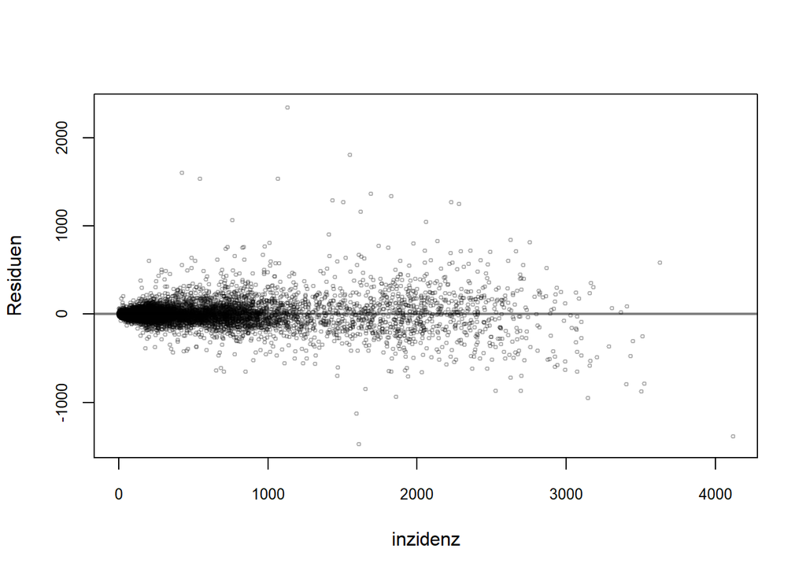

```
## integer(0)
```

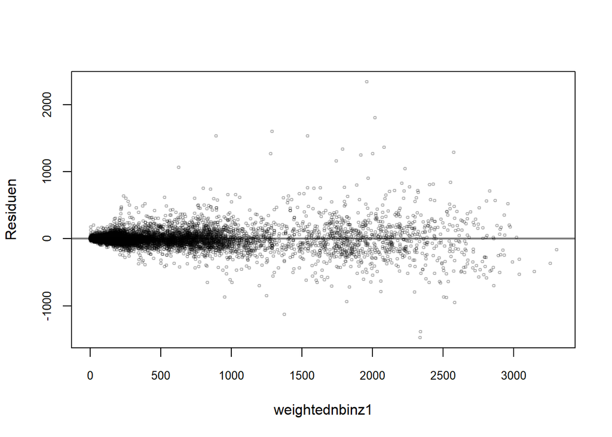

```
## integer(0)
```

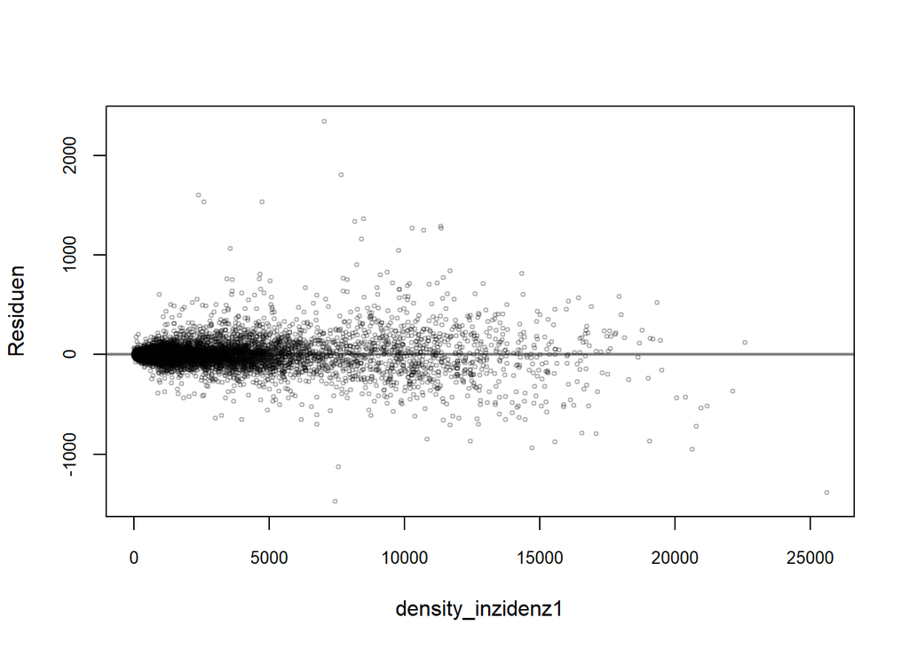

```
## integer(0)
```

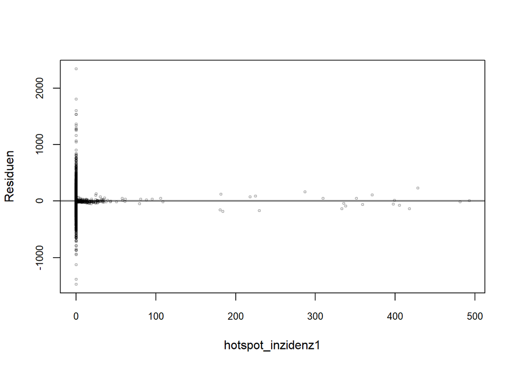

```
## integer(0)
```

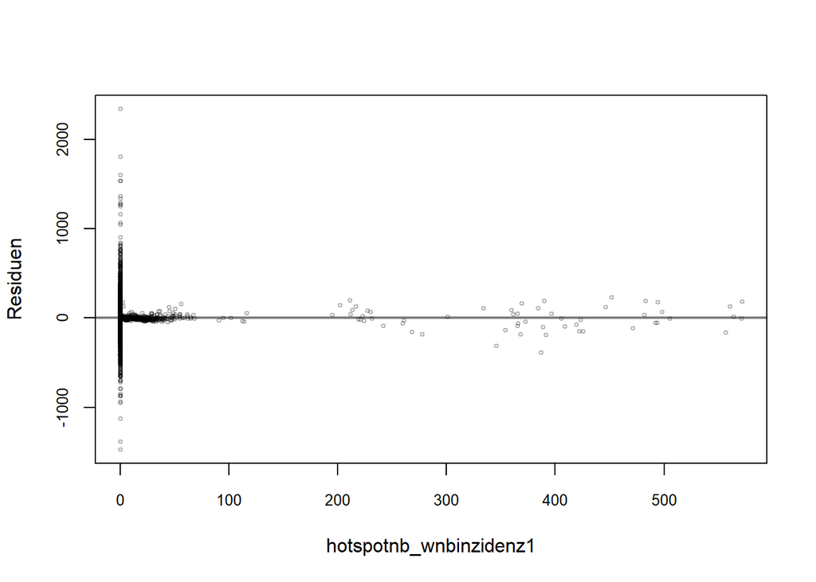

```
## integer(0)
```

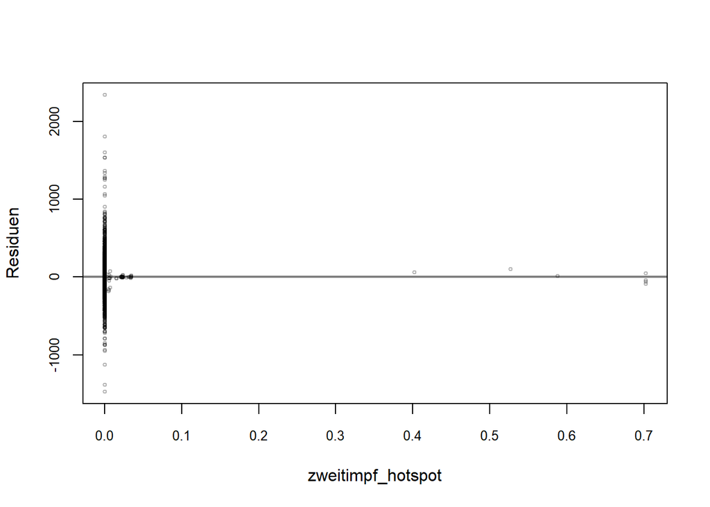

```
## integer(0)
```

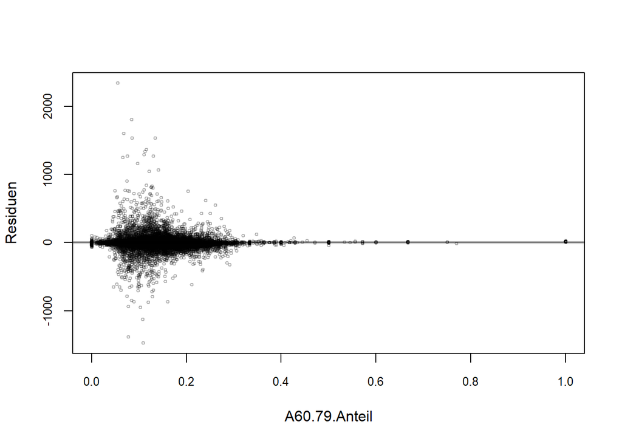

```
## integer(0)
```